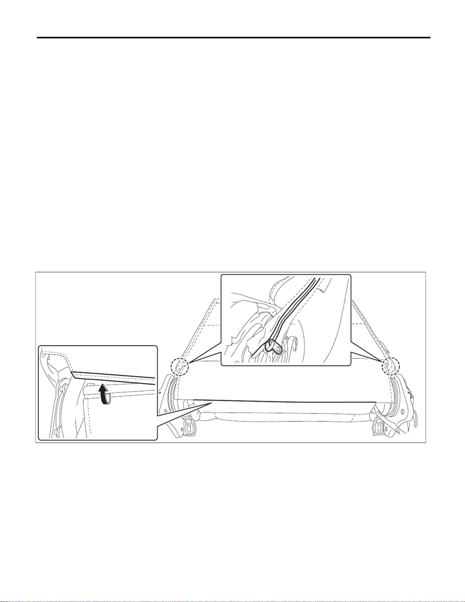

AB-43

Side Airbag Module

AIRBAG SYSTEM

7. Side Airbag Module

A: REMOVAL

CAUTION:

CAUTION, General Description.>

1) Turn the ignition switch to OFF.

NT-5, BATTERY, NOTE, Note.>

NOTE:

• For models other than STI model, disconnect the ground terminal from battery sensor.

• For model with the power seat, move the seat to the front-most position before removing the battery

ground terminal.

3) Remove the front seats. <Ref. to SE-9, REMOVAL, Front Seat.>

Seat.>

5) Remove the side airbag module.

CAUTION:

Do not open the protective cover of the side airbag module. If any damage is present in the protective

cover or the cloth of side airbag module comes out from the protective cover slit, replace the side air-

bag module with a new part.

(1) Remove the plastic fastener at the back side (bottom) of backrest assembly.

(2) Open the fastener at the rear side of backrest assembly.

(3) Remove the hexagon cap nut and nuts.

SE-01332

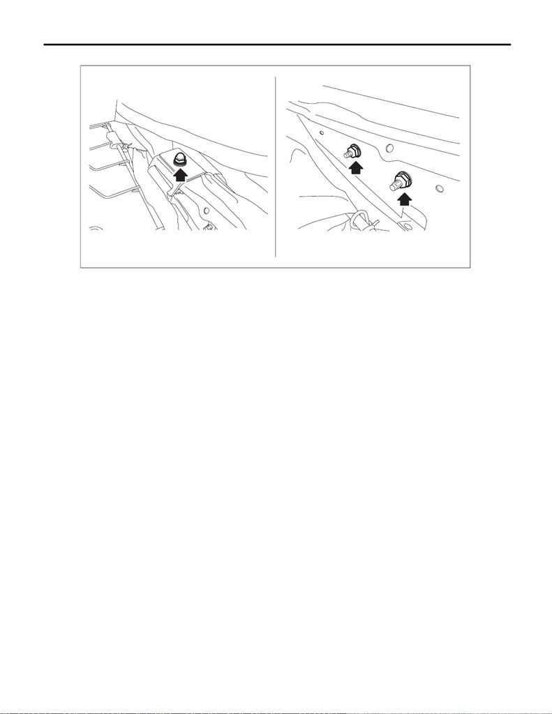

AB-44

Side Airbag Module

AIRBAG SYSTEM

(4) While taking care not to damage the airbag protective cover, remove the side airbag module.

SE-01304

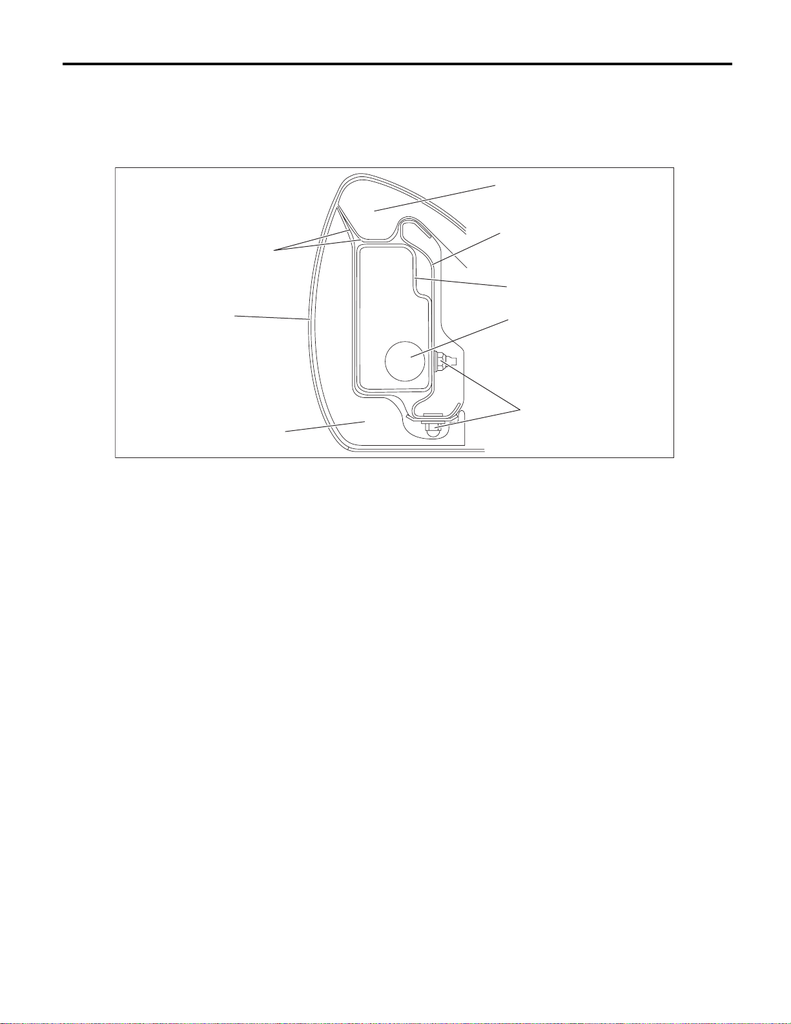

AB-45

Side Airbag Module

AIRBAG SYSTEM

B: INSTALLATION

CAUTION:

CAUTION, General Description.>

• Make sure that the side airbag module is installed as shown in the figure.

• Be careful not to stain or damage the cover COMPL - front backrest during assembly.

• Do not reuse hog rings.

• Secure the hog ring using hog ring pliers.

• Install the hog rings to the specified points securely and make sure that there is no wrinkle or

twisting on the cover COMPL - front backrest.

1) Before installation, inspect the following items and replace any faulty part with a new one.

• Make sure that there is no foreign matter on side airbag module.

• Front seat, airbag module and mounting bracket are damaged or deformed.

• Harness and/or connector is cracked, deformed or open.

• Harness wire is exposed.

2) Install the side airbag module to the frame assembly - front backrest.

Tightening torque:

6 N·m (0.6 kgf-m, 4.4 ft-lb)

3) Assemble the front seat. <Ref. to SE-23, ASSEMBLY, Front Seat.>

CAUTION:

After restoring the seat, operate the reclining and sliding mechanisms to check that the side airbag

harness is not caught.

4) Install the front seat assembly to the body. <Ref. to SE-10, INSTALLATION, Front Seat.>

5) Connect the battery ground terminal. <Ref. to NT-5, BATTERY, NOTE, Note.>

NOTE:

For models other than STI model, connect the ground terminal to battery sensor.

(1) Pad ASSY - front seat backrest (4) Side airbag module inflator (7) Side airbag guide cloth

(2) Frame ASSY - front backrest (5) Nut

(3) Side airbag module protective

cover

(6) Cover COMPL - front backrest

SE-01335